# AMI Program Implementation Assessment

Water-use analysis, anomaly detection, and conservation targeting

Prepared with R + Snowflake

May 29, 2026

## Executive summary

This assessment demonstrates an end-to-end Advanced Metering Infrastructure (AMI) analysis workflow built in **R** on data managed in **Snowflake**. It processes hourly interval reads to (1) characterize water-use patterns, (2) automatically flag anomalies such as leaks and meter errors, (3) segment customers for targeted conservation, and (4) quantify non-revenue water (NRW).

Dataset at a glance

| Metric | Value |
| --- | --- |
| Meters analyzed | 60 |
| Hourly interval reads | 129,600 |
| Period | 2025-04-01 to 2025-06-29 |
| Total metered volume (gal) | 4,751,289 |

> **Note on data.** This report runs on a realistic *synthetic* AMI dataset so it is fully reproducible without exposing client data. The identical workflow reads from a live Snowflake warehouse when credentials are configured (`source = "snowflake"`). See `README.md` for the data dictionary and the Snowflake DDL in `sql/`.

## 1. Water-use patterns

### System-wide daily demand

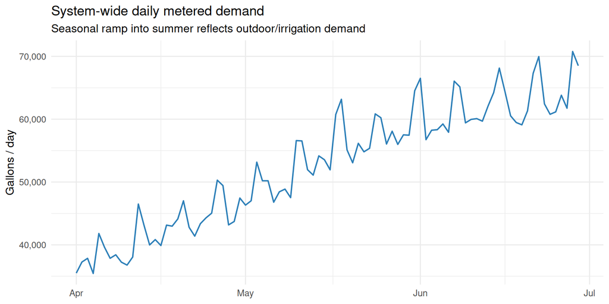

### Diurnal profile by customer class

Different customer classes have distinct daily signatures. Residential demand is twin-peaked (morning and evening); commercial accounts plateau through business hours; irrigation concentrates in pre-dawn and evening watering windows. These shapes drive both demand forecasting and anomaly baselines.

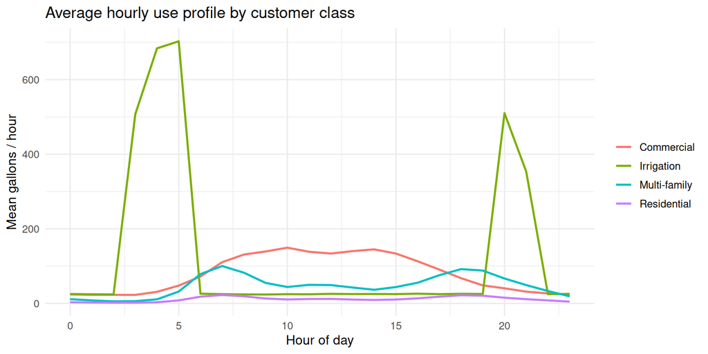

## 2. Anomaly detection

We run four transparent, parameterized detectors over the interval reads. Each is designed to be **replicable across clients** by adjusting thresholds:

| Detector | Signal | Typical cause |
| --- | --- | --- |
| **Leak** | Sustained step-up in overnight minimum flow (net of seasonal growth) | Underground/service-line leak, stuck fixture |
| **Continuous use** | Meter essentially never reads zero | Running toilet, stuck valve, process load |
| **Stuck meter** | Long run of identical/zero reads | Register failure, lost AMI comms, vacancy |
| **Meter error** | Negative or physically impossible reads | Register rollover, AMI decode error |

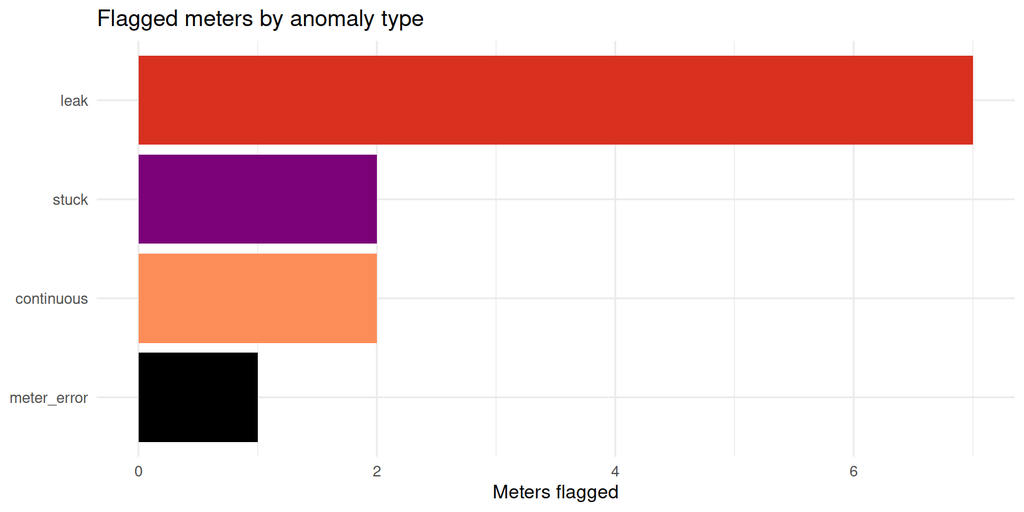

### Detector validation

Because the synthetic data carries known *ground-truth* anomalies, we can score the detectors directly — evidence the methods actually work rather than just producing plausible-looking output.

Detection performance vs. injected ground truth

| true_positive | false_positive | false_negative | precision | recall |
| --- | --- | --- | --- | --- |
| 9 | 3 | 0 | 0.75 | 1 |

### Highest-priority leaks

Estimated wasted volume helps prioritize field crews and customer outreach.

Top leak candidates by estimated wasted volume

| meter_id | customer_class | route_id | median_overnight_flow_gph | est_wasted_gallons |
| --- | --- | --- | --- | --- |
| M00023 | Irrigation | R05 | 82.24 | 50003 |
| M00010 | Commercial | R04 | 71.10 | 38836 |
| M00037 | Residential | R03 | 11.33 | 8158 |
| M00041 | Residential | R01 | 9.88 | 7114 |
| M00007 | Commercial | R06 | 7.61 | 5476 |
| M00012 | Commercial | R07 | 6.35 | 4572 |
| M00044 | Irrigation | R06 | 8.21 | 3363 |

## 3. Customer segmentation

Behavioural features (peakiness, overnight share, weekday/weekend ratio, seasonal sensitivity) classify customers independent of their billing class — portable across utilities. We show a transparent rule-based tiering plus an unsupervised k-means discovery view.

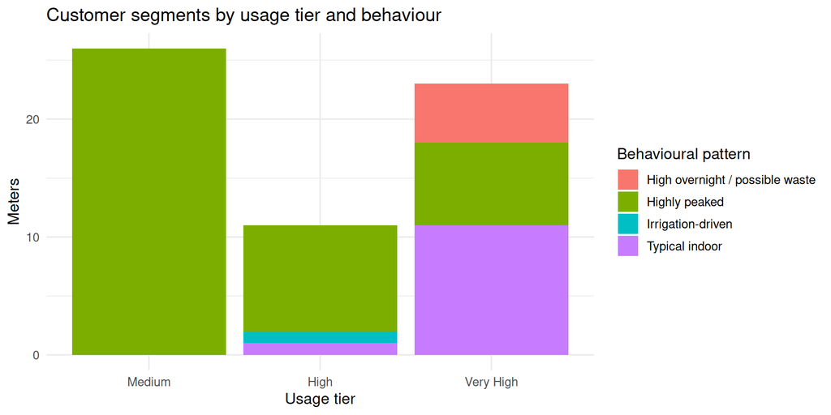

K-means cluster profiles (mean feature values)

| cluster | n_meters | avg_daily_gal | peak_to_median | night_share | summer_ratio |
| --- | --- | --- | --- | --- | --- |
| 1 | 6 | 3215.5 | 63.0 | 0.344 | 1.34 |
| 4 | 45 | 702.8 | 11.1 | 0.041 | 1.27 |
| 2 | 3 | 335.6 | 11.8 | 0.073 | 1.72 |
| 3 | 6 | 144.2 | 7495.0 | 0.034 | 1.30 |

## 4. Non-revenue water (NRW)

NRW is the gap between water supplied into the system and water metered to customers — a key efficiency and loss-control metric.

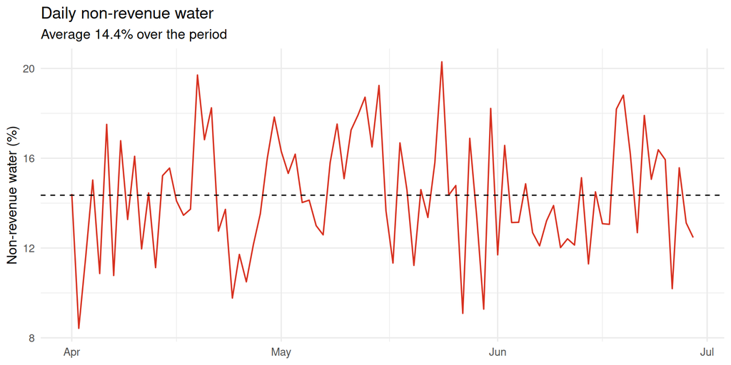

## 5. Recommendations

Typical roadmap actions an analyst would draw from these results:

1. **Dispatch leak investigations** to the top-ranked overnight-flow meters, starting with the highest estimated wasted volume.
2. **Customer outreach** to continuous-use and high-overnight accounts (often a running toilet — a low-cost, high-impact fix).
3. **Data-quality remediation** for meters reporting negative/stuck reads before they corrupt billing and downstream analytics.
4. **Targeted conservation** to “Very High” tier and irrigation-driven segments, where per-account savings potential is largest.
5. **Track NRW** against the dashed baseline; sustained increases warrant a district-metered-area (DMA) loss audit.

*Reproduce this report:* run `R/01_generate_synthetic_ami.R` then knit this file (`rmarkdown::render("reports/ami_assessment.Rmd")`), or point it at Snowflake by configuring `config.yml` and setting `SNOWFLAKE_PASSWORD`.